# Fatores associados ao sentimento de prejuízo no processo de aprendizagem

Itália Tatiana Bordin and [Henrique Laureano](https://henriquelaureano.github.io/)

Last modification on* 2022-01-29 11:50:35

# Dados

> 20 covariáveis e 176 indivíduos/alunos. Retiramos os que disseram `Não sei responder` em relação à resposta que renomeei como `Prejuízo`, ficando assim com 176 alunos.

> Abaixo mostramos o nome das 20 covariáveis utilizadas (com a resposta, 21). Renomeei o nome de todas (e os níveis de algumas) para facilitar e até mesmo viabilizar a análise. Contudo, acredito que pelos nomes dados todas são intendíveis (de qualquer modo, lhe enviei por email planilha excel com apenas essas variáveis já renomeadas).

```
 [1] "Idade"                               "Gênero"
 [3] "UF"                                  "Deficiência_ou_necessidade_especial"
 [5] "Área"                                "Ensino_Remoto"
 [7] "Abandonou_ou_trancou_matrícula"      "Equipamento_eletrônico"
 [9] "Internet"                            "Situação_Ensino_Remoto"
[11] "Horas_Ensino_Remoto"                 "Concentração"
[13] "Aulas"                               "Prejuízo"
[15] "Interação_remota_professor"          "Interação_remota_colegas"
[17] "Atendimento_professor"               "Universidade"
[19] "Faixa_etária"                        "Nível"
[21] "Disciplinas_simultâneas"
```

> Além disso alguns agrupamentos foram feitos, dado que o ajuste do modelo ficou comprometido dado a baixa representatividade de dados em alguns níveis de algumas variáveis. Na variável `UF` os estados foram agrupados em regiões do Brasil, e na variável `Atendimento_professor` os 3 alunos que disseram `Busquei atendimento e não obtive resposta.` foram alocados junto dos que disseram `Busquei atendimento e obtive resposta insatisfatória.`, tal novo nível foi chamado de `Insatisfatória`.

# Regressão logística

> Primeiro ajustados o modelo com todas as variáveis e vemos os resíduos (análise de resíduos).

> Na esquerda temos um gráfico quantil-quantil (qq-plot), para uma distribuição uniforme (a distribuição esperada), para detectar possíveis desvios da mesma. Testes de hipótese são apresentados para melhor corroborar tais possíveis desvios, p-valores não significativos (maiores que 0.05) indicam que está tudo bem (pressupostos são atendidos). Na direita temos um gráfico dos resíduos contra os valores preditos/ajustados. Vemos um possível outlier e um padrão um pouco cíclico. Dado que está tudo bem no qq-plot e que temos apenas um possível outlier, tal padrão não parece ser um problema (tal comportamento é muito provavelmente causado por alguma(s) covariável desbalanceada - nível com poucas observações ou observações de apenas uma classe da resposta).

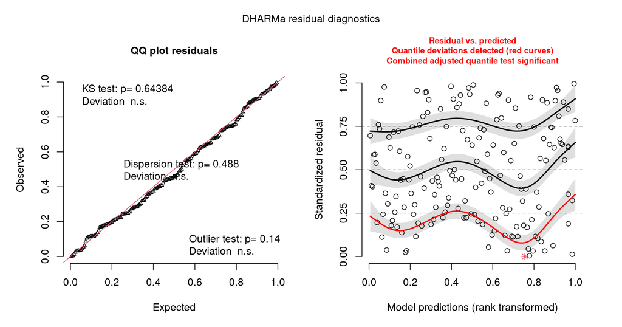

> A curva ROC apresenta uma alta área abaixo da curva (AUC), indicando que dentre as variáveis existem boas preditoras para o desfecho em questão.

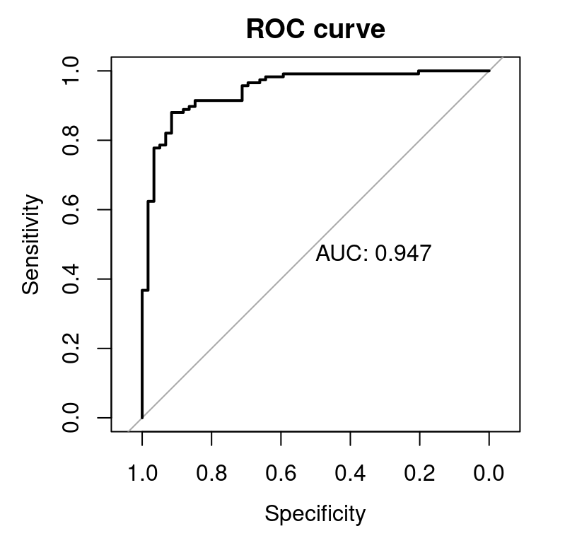

> Performamos seleção de variáveis via o critério de Akaike (AIC) num esquema *stepwise*.

> O modelo completo/inicial possuí um AIC de 201.74. A variável cuja retirada tem maior impacto no AIC, ou seja, a menos relevante/significativa, é a `internet`. Um modelo sem essa variável possuí um AIC de 197.55. Com esse novo modelo, vemos que a variável menos relevante é a `Interação_remota_colegas` (AIC de 194.54). Assim procedemos até chegar no modelo final.

```
Start:  AIC=201.74
Prejuízo ~ Idade + Gênero + UF + Deficiência_ou_necessidade_especial +
    Área + Ensino_Remoto + Abandonou_ou_trancou_matrícula +
    Equipamento_eletrônico + Internet + Situação_Ensino_Remoto +
    Horas_Ensino_Remoto + Concentração + Aulas + Interação_remota_professor +
    Interação_remota_colegas + Atendimento_professor + Universidade +
    Faixa_etária + Nível + Disciplinas_simultâneas

                                      Df Deviance    AIC
- Internet                             3   103.55 197.55
- Interação_remota_colegas             2   102.58 198.59
- Idade                                1   101.75 199.75
- Nível                                1   101.75 199.75
- Universidade                         1   101.77 199.77
- Abandonou_ou_trancou_matrícula       1   101.81 199.81
- Deficiência_ou_necessidade_especial  4   108.30 200.30
- Faixa_etária                         1   102.51 200.51
- Disciplinas_simultâneas              3   106.52 200.52
- Ensino_Remoto                        1   102.64 200.64
- UF                                   4   109.33 201.33
<none>                                     101.74 201.74
- Horas_Ensino_Remoto                  4   110.03 202.03
- Equipamento_eletrônico               2   106.26 202.26
- Situação_Ensino_Remoto               2   107.08 203.08
- Gênero                               2   107.53 203.53
- Área                                 8   120.61 204.61
- Interação_remota_professor           2   110.59 206.59
- Atendimento_professor                2   111.56 207.56
- Aulas                                3   116.76 210.76
- Concentração                         2   129.48 225.48

Step:  AIC=197.55
Prejuízo ~ Idade + Gênero + UF + Deficiência_ou_necessidade_especial +
    Área + Ensino_Remoto + Abandonou_ou_trancou_matrícula +
    Equipamento_eletrônico + Situação_Ensino_Remoto + Horas_Ensino_Remoto +
    Concentração + Aulas + Interação_remota_professor + Interação_remota_colegas +
    Atendimento_professor + Universidade + Faixa_etária + Nível +
    Disciplinas_simultâneas

                                      Df Deviance    AIC
```

[output cut: 404 more lines]

```
+ Universidade                         1   145.54 169.54
+ Ensino_Remoto                        1   145.68 169.68
+ Nível                                1   145.70 169.70
- Aulas                                3   153.83 169.83
+ Gênero                               2   144.02 170.02
+ Situação_Ensino_Remoto               2   144.10 170.10
+ Internet                             3   142.15 170.15
- Atendimento_professor                2   152.59 170.59
+ Interação_remota_colegas             2   144.88 170.88
+ Horas_Ensino_Remoto                  4   141.46 171.46
+ Deficiência_ou_necessidade_especial  4   141.92 171.92
+ Disciplinas_simultâneas              3   144.48 172.48
+ UF                                   4   143.36 173.36
+ Área                                 8   136.54 174.54
- Concentração                         2   175.06 193.06
```

> Abaixo temos a análise de resíduos do modelo final:

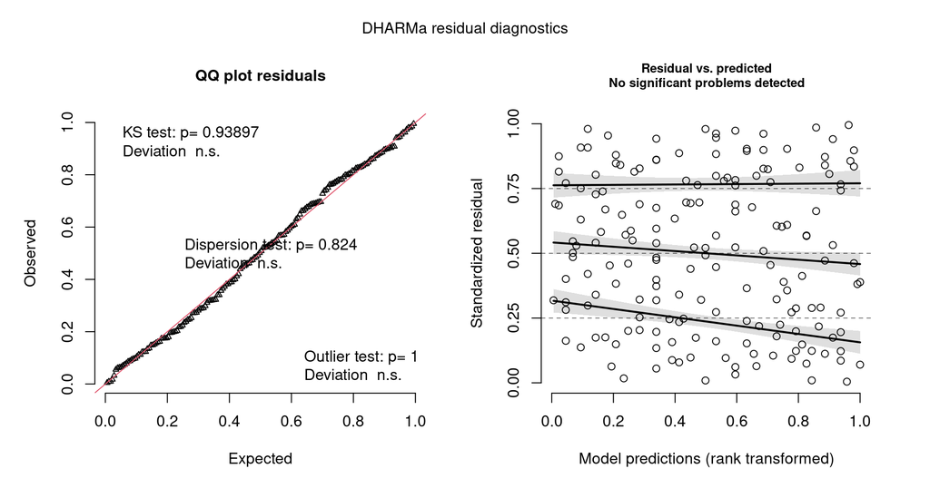

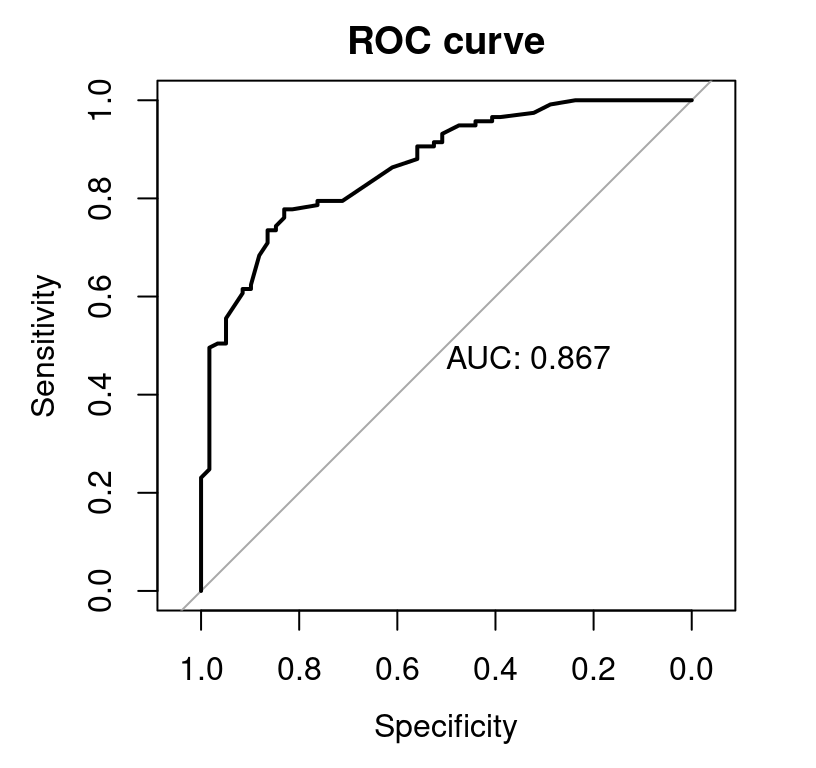

> Está tudo ok com a análise de resíduos, nenhuma não-conformidade.

> A seguir temos a tabela de análise de variância (ANOVA) do modelo final. Das 20 covariáveis inseridas no modelo inicial, terminamos num modelo com 5 covariáveis.

|  | LR Chisq | Df | Pr(>Chisq) |
| --- | --- | --- | --- |
| Concentração | 29.306229 | 2 | 0.00000043 |
| Aulas | 8.078994 | 3 | 0.04440704 |
| Interação_remota_professor | 5.704637 | 2 | 0.05771036 |
| Atendimento_professor | 6.838825 | 2 | 0.03273165 |
| Faixa_etária | 2.405848 | 1 | 0.12088263 |

> Finalmente, a tabela com os resultados finais. Temos, da esquerda para a direita: Nome da variável; estimativa pontual ($\hat{\beta}$); erro padrão da estimativa pontual; estatística *z*; *p*-valor; probabilidade estimada de se sentir com o aprendizado prejudicado; chance/odds; *lower bound* do intervalo de 95% da chance; *upper bound* do intervalo de 95% da chance.

> No intercepto (nível de referência) temos um aluno de
> - `Concentração` Baixa;
> - `Aulas` 100% assíncronas;
> - `Interação_remota_professor` Pouco;
> - `Atendimento_professor` Insatisfatória;
> - `Faixa_etária` até 25 anos.

> Sua probabilidade de se sentir com o aprendizado prejudicado é de 94.3%. Se mudamos para um diferente nível de `Concentração` (Parcial ou Alta), `Atendimento_professor` (Satisfatória ou Sem necessidade) ou de `Faixa etária` mais de 25 anos, sua probabilidade diminui e consequentemente suas chances (comparado ao perfil do intercepto) são **menores** que 1 (mesmo se não tivéssemos calculado as probabilidades e chances seríamos capazes de saber isso pelo fato dos coeficientes estimados serem **negativos**).

> Se mudamos para um diferente nível de `Aulas` (Em maior parte, assíncronas; Em maior parte, síncronas; ou 100% síncronas) ou de `Interação_remota_professor` (Parcialmente ou Muito) as probabilidades e chances de se sentir com o aprendizado prejudicado, aumentam. As maiores razões de chances são observados na variável `Aulas`.
> - Um aluno com `Aulas` 100% síncronas tem uma chance 19 vezes **maior** de se sentir com o aprendizado prejudicado do que um aluno com `Aulas` 100% assíncronas;
> - Um aluno com `Aulas` Em maior parte, síncronas, tem uma chance 10 vezes **maior** de se sentir com o aprendizado prejudicado do que um aluno com `Aulas` 100% assíncronas.

> As chances menores que 1 podem ser interpretados como 1/chance:
> - Um aluno com `Concentração` Parcial tem uma chance 25 (1/0.04) vezes **menor** de se sentir com o aprendizado prejudicado do que um aluno com `Concentração` Baixa;
> - Um aluno com `Concentração` Alta tem uma chance 100 (1/0.01) vezes **menor** de se sentir com o aprendizado prejudicado do que um aluno com `Concentração` Baixa.

| Variavel | Estimate | Std. Error | z value | Pr(>\|z\|) | Prob | Chance | 2.5 % | 97.5 % |
| --- | --- | --- | --- | --- | --- | --- | --- | --- |
| (Intercept) | 2.81460 | 1.34945 | 2.08574 | 0.03700 | 0.94346 | 16.68643 | 1.47396 | 355.71986 |
| ConcentraçãoParcial | -3.18799 | 0.95969 | -3.32189 | 0.00089 | 0.40772 | 0.04125 | 0.00434 | 0.21082 |
| ConcentraçãoAlta | -4.54568 | 1.09439 | -4.15364 | 0.00003 | 0.15045 | 0.01061 | 0.00088 | 0.07147 |
| AulasEm maior parte, assíncronas | 1.43368 | 1.35896 | 1.05498 | 0.29143 | 0.98591 | 4.19410 | 0.24602 | 61.47245 |
| AulasEm maior parte, síncronas | 2.30623 | 1.34533 | 1.71425 | 0.08648 | 0.99406 | 10.03650 | 0.62824 | 146.55862 |
| Aulas100% síncronas | 2.95226 | 1.38489 | 2.13176 | 0.03303 | 0.99688 | 19.14909 | 1.11812 | 304.75670 |
| Interação_remota_professorParcialmente | 1.11932 | 0.82186 | 1.36193 | 0.17322 | 0.98081 | 3.06278 | 0.59157 | 16.06908 |
| Interação_remota_professorMuito | 0.10729 | 0.85256 | 0.12585 | 0.89985 | 0.94892 | 1.11326 | 0.20222 | 6.15030 |
| Atendimento_professorSatisfatória | -1.91307 | 0.80225 | -2.38463 | 0.01710 | 0.71126 | 0.14763 | 0.02562 | 0.63573 |
| Atendimento_professorSem necessidade | -1.64220 | 0.87731 | -1.87187 | 0.06123 | 0.76358 | 0.19355 | 0.02959 | 0.98169 |
| Faixa_etáriamais de 25 anos | -0.69957 | 0.45283 | -1.54488 | 0.12237 | 0.89235 | 0.49680 | 0.20153 | 1.20279 |

> Para terminar, equação do modelo:

$$\begin{aligned}
\log\left[ \frac { \widehat{P( \operatorname{Prejuízo} = \operatorname{1} )} }{ 1 - \widehat{P( \operatorname{Prejuízo} = \operatorname{1} )} } \right] &= 2.81 - 3.19(\operatorname{Concentração}_{\operatorname{Parcial}})\\
&\quad - 4.55(\operatorname{Concentração}_{\operatorname{Alta}}) + 1.43(\operatorname{Aulas}_{\operatorname{Em\ maior\ parte,\ assíncronas}})\\
&\quad + 2.31(\operatorname{Aulas}_{\operatorname{Em\ maior\ parte,\ síncronas}}) + 2.95(\operatorname{Aulas}_{\operatorname{100\%\ síncronas}})\\
&\quad + 1.12(\operatorname{Interação\_remota\_professor}_{\operatorname{Parcialmente}}) + 0.11(\operatorname{Interação\_remota\_professor}_{\operatorname{Muito}})\\
&\quad - 1.91(\operatorname{Atendimento\_professor}_{\operatorname{Satisfatória}}) - 1.64(\operatorname{Atendimento\_professor}_{\operatorname{Sem\ necessidade}})\\
&\quad - 0.7(\operatorname{Faixa\_etária}_{\operatorname{mais\ de\ 25\ anos}})
\end{aligned}$$

# Referências

> R Core Team (2021). R: A language and environment for statistical computing. R Foundation for Statistical Computing, Vienna, Austria. URL https://www.R-project.org/.

> Hadley Wickham, Romain François, Lionel Henry and Kirill Müller (2021). dplyr: A Grammar of Data Manipulation. R package version 1.0.7. https://CRAN.R-project.org/package=dplyr

> Florian Hartig (2021). DHARMa: Residual Diagnostics for Hierarchical (Multi-Level / Mixed) Regression Models. R package version 0.4.4. https://CRAN.R-project.org/package=DHARMa

> Venables, W. N. & Ripley, B. D. (2002) Modern Applied Statistics with S. Fourth Edition. Springer, New York. ISBN 0-387-95457-0

> John Fox and Sanford Weisberg (2019). An {R} Companion to Applied Regression, Third Edition. Thousand Oaks CA: Sage. URL: https://socialsciences.mcmaster.ca/jfox/Books/Companion/

> Xavier Robin, Natacha Turck, Alexandre Hainard, Natalia Tiberti, Frédérique Lisacek, Jean-Charles Sanchez and Markus Müller (2011). pROC: an open-source package for R and S+ to analyze and compare ROC curves. BMC Bioinformatics, 12, p. 77. DOI: 10.1186/1471-2105-12-77 http://www.biomedcentral.com/1471-2105/12/77/

> Alan Agresti (2002). Categorical Data Analysis. New York: Wiley-Interscience. ISBN 978-0-471-36093-3

> David Hosmer (2013). Applied logistic regression. Hoboken, New Jersey: Wiley. ISBN 978-0470582473

> Frank E. Harrell (2015). Regression Modeling Strategies. Springer Series in Statistics (2nd ed.). New York; Springer. doi:10.1007/978-3-319-19425-7. ISBN 978-3-319-19424-0